# Concepts: Correlations and model fit

This week, we’ll talk about three related metrics that describe how well the relationships between variables can be described as a particular linear relationship.

- Correlation
- R-squared
- Standard error of regression

# Correlation

The correlation between two variables describes how closely the relationship between two variables approximates a linear relationship, and whether that relationship is positive (higher values corresponding to higher values) or negative (higher values corresponding to lower values). Possible correlation values range from -1.0 to 1.0.

All of these scatter plots show a correlation of 1.0.

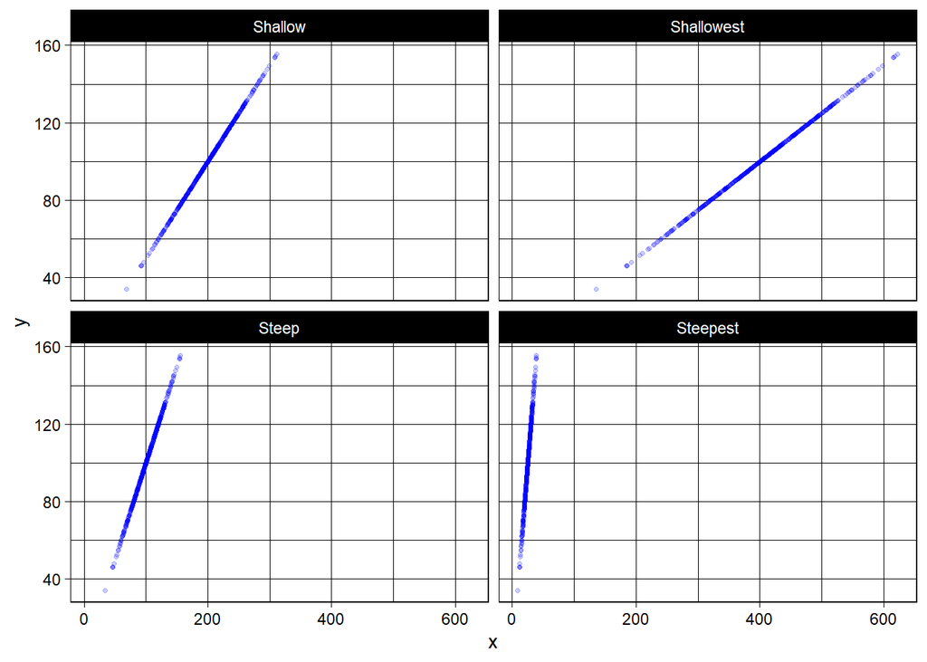

```r
library(tidyverse)

data <- tibble(y = rnorm(500, mean = 100, sd = 20)) |>
  mutate(Steepest = y/4,
         Steep = y,
         Shallow = y*2,
         Shallowest = y*4) |>
  pivot_longer(cols = c(-y),
               names_to = "kind",
               values_to = "x")

ggplot(data, aes(x =x, y = y)) +
  geom_point(alpha = 0.2, color = "blue", shape = 20) +
  facet_wrap(facets = vars(kind),
             nrow = 2) +
  theme_linedraw()
```

All of these ones show a correlation of -1.0.

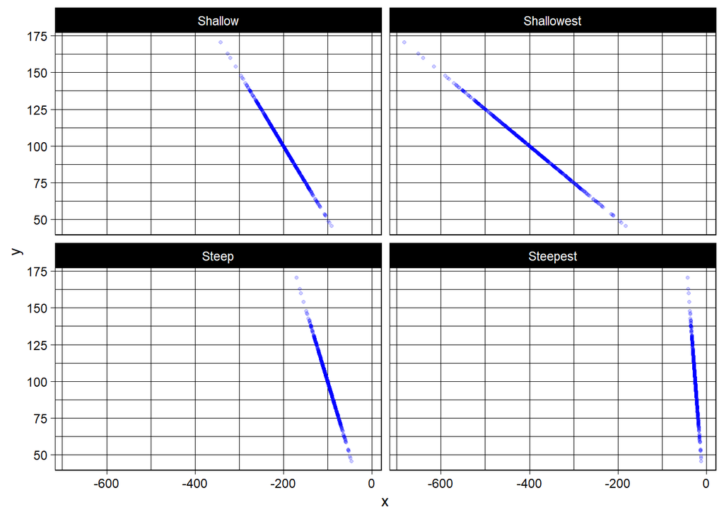

```r
data <- tibble(y = rnorm(500, mean = 100, sd = 20)) |>
  mutate(Steepest = -y/4,
         Steep = -y,
         Shallow = -y*2,
         Shallowest = -y*4) |>
  pivot_longer(cols = c(-y),
               names_to = "kind",
               values_to = "x")

ggplot(data, aes(x =x, y = y)) +
  geom_point(alpha = 0.2, color = "blue", shape = 20) +
  facet_wrap(facets = vars(kind),
             nrow = 2) +
  theme_linedraw()
```

All of these show a correlation of zero.

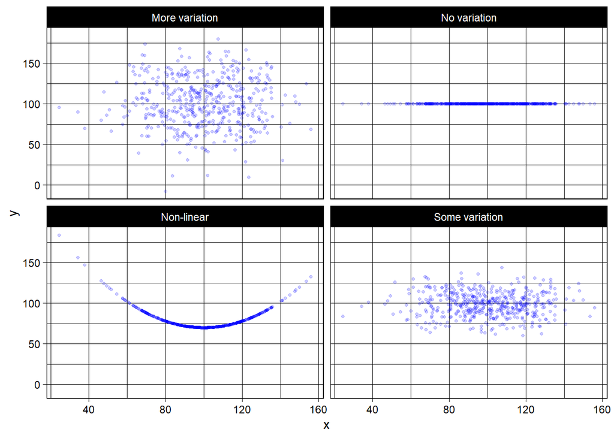

```r
data <- tibble(x = rnorm(500, mean = 100, sd = 20)) |>
  mutate(`No variation` = 100,
         `Some variation` = rnorm(500, mean=100, sd = 15),
         `More variation` = rnorm(500, mean=100, sd = 30),
         `Non-linear` = ((x-100)^2)/50 + 70) |>
  pivot_longer(cols = c(-x),
               names_to = "kind",
               values_to = "y")

ggplot(data, aes(x =x, y = y)) +
  geom_point(alpha = 0.2, color = "blue", shape = 20) +
  facet_wrap(facets = vars(kind),
             nrow = 2) +
  theme_linedraw()
```

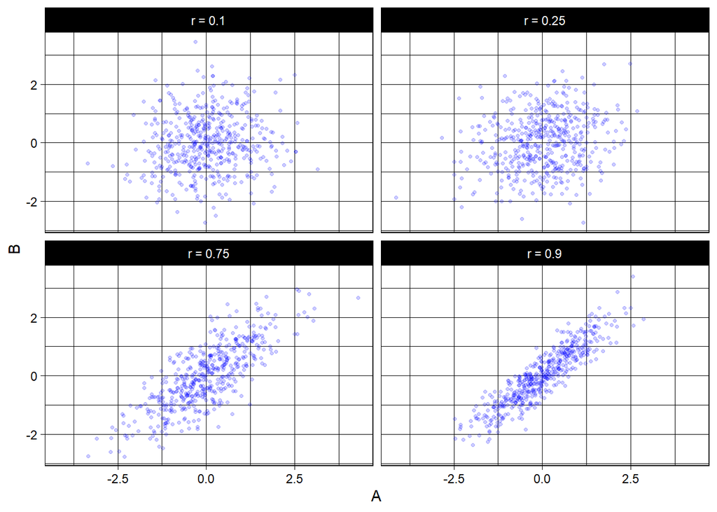

```r
library(faux)

data1 = rmulti(n = 500,
              r = 0.1) |>
  mutate("Correlation" = "r = 0.1")

data2 = rmulti(n = 500,
               r = 0.25) |>
  mutate("Correlation" = "r = 0.25")

data3 = rmulti(n = 500,
              r = 0.75) |>
  mutate("Correlation" = "r = 0.75")

data4 = rmulti(n = 500,
               r = 0.9) |>
  mutate("Correlation" = "r = 0.9")


data = rbind(data1, data2) |>
  rbind(data3) |>
  rbind(data4)

ggplot(data, aes(x =A, y = B)) +
  geom_point(alpha = 0.2, color = "blue", shape = 20) +
  facet_wrap(facets = vars(Correlation),
             nrow = 2) +
  theme_linedraw()
```

# R-squared

When you estimate a regression model with a single continuous predictor, the the square of the correlation between the two variables (the predictor and the outcome) is a value called R-squared. R squared can be interpreted as the percentage of the variation in the outcome that can be predicted by the predictor(s).

You can also calculate an R-squared value for a regression with multiple predictors, although in that case, there isn’t a corresponding correlation value.

R-squared is a very widely-used measure of model fit.

# Standard error of regression

Another measure of model fit is the standard error of the regression.

Here’s how I think of the standard error of regression: If there was a a set of predictors that *could* perfectly predict an outcome, and you estimated a regression model that left out one of them, the standard error of the regression would be the standard deviation of the variable you left out.

You can use the standard error of regression to construct a confidence interval around a predicted outcome produced by the model.